# Rodgers_FinalProject

Mary E. Rodgers

2023-05-15

# **1 Introduction**

Seven to 10 children out of every 100 will be diagnosed with a specific language impairment (SLI) by the time they reach kindergarten by exhibiting symptoms of delays in language development (e.g., speaking, listening, reading and writing skills [2]. Specific symptoms include impairments in vocabulary and grammar [3], which are comorbid with challenging behavior [4]. Several standardized measures can be used to identify delays in expressive (i.e., saying) and receptive (i.e., understanding) language development such as Preschool Language Scales [5] through the production of a standard score and an age equivalence. However, understanding a child’s current level of language development can also be assessed through transcripts of their language, viewed in stages of syntactical and morphological development [6] or through descriptive data such as the mean length of utterance or total number of words [7]. By understanding the components found within transcripts of SLI and typically developing (TD) children, transcript data can be used to predict if a child will receive a diagnosis of SLI. The objective of the current study was to develop a logistic regression model that could predict SLI or TD status based off of pre-determined language metrics derived from transcripts using R Studio [8]. In order to do this, a principal component analysis (PCA) on the transcript data of SLI and TD children will be conducted in order to create predictor variables. Then, machine learning methods will be used to run a logistic regression between the predictor components and the outcome variable of SLI or TD status.

## *1.1 Research Questions*

Our primary research question was: 1) What linguistic features predict SLI?

Our secondary research question was: 2) Can the model accurately predict SLI or TD status to a significant degree?

## *1.2 Data*

The current data set was obtained from kaggle.com from user DGOKE1, containing 1163 instances of language data derived from transcripts of children between the ages of four to fifteen completing a wordless picture task [9, 10, 11]. This particular data set was created from three different data sets. The data set description on Kaggle indicated 1163 children, 919 typically developing and 346 with SLI. Further analysis of the data indicated that 267 children with SLI were in the data set. These children along with 267 randomly selected TD children were included in the analysis, analyzed using several R packages [13-22].

The variables representing raw transcript data from the child that were included in this analysis were:

- child_TNW, the total number of words
- child_TNS, the total number of sentences
- freq_ttr, the frequency of word types to work token ratio
- r_2_i_verbs, the ratio of raw to inflected verbs
- mor_words, the number of words in the mor tier
- num_pos_tags, the number of different part-of-speech tags
- n_dos, the number of times the child says ‘do’
- repetition, the number of repetitions
- retracing, the number of times an utterance is abandoned and continues again
- fillers, the number of filler words (e.g., um, uh)
- average_syl, the average number of syllables per word
- mlu_words, the mean length of the words
- mlu_morphemes, the mean length of sentences
- verb_utt, the number of utterances consisting of verbs
- present_progressive, the number of present progressives
- preposition_in, the number of times ‘in’ is used
- preposition_on, the number of times ‘on’ is used
- plural_s, the number of times a plural is used
- irregular_past_tense, the number of times an irregular past tense is used
- posessive_s, the number of times a posessive is used
- uncontractible_copula, the number of times an uncontractible copula is used
- articles, the number of articles (i.e., a, an, the)
- regular_past_ed, the number of times a regular past tense is used
- regular_3rd_person_s, the number of times a regular third person is used
- uncontractible_aux, the number of times an uncontractible auxiliary is used
- contractible_copula, the number of times a contractible copula is used
- contractible_aux, the number of times a contractible auxiliary verb is used
- word_errors, the number of word errors in the transcript
- n_v, the number of nouns followed by a verb
- n_aux, the number nouns followed by an auxiliary verbs
- n_3s_v, the number of third singular nouns followed by a verb
- det_n_pl, the number of determinant nouns followed by a personal pronoun
- det_pl_n, the number of determinant pronouns followed by a noun
- pro_aux, the number of pronouns followed by an auxiliary verb
- pro_3s_v, the number of singular nominative pronouns followed by a verb

Source: https://www.kaggle.com/datasets/dgokeeffe/specific-language-impairment

## *1.3 Git Hub*

https://github.com/Mary-E-Rodgers/FinalProject_PCA_ML_LogisticRegression_TranscriptData

# **2 Methods**

## *2.1 Data wrangling*

### 2.1.1 Preparing R

First we connected to the CRAN mirror, cleared the global environment, and pulled in the necessary R packages.

```r
options(repos=c(CRAN="https://mirrors.nics.utk.edu/cran/"))

rm(list=ls(all=TRUE))

library(tidyverse) # this package contains tools for data cleaning and organization
```

```r
library(ggplot2) # this is used for data visualization
library(dplyr) # this contains tools for data manipulation
library(caret) # this contains functions for classification and regression raining
library(car) # this is for variance inflation factor (VIF)
library(corrplot) # this package is for visualizing your correlation
library(relaimpo) # this is for variable importance
library(PerformanceAnalytics) # this contains tools for performance and risk analysis
library(glmnet) # this is for modeling generalized linear models
library(psych) # this is for descriptive statistics
library(stringr) #  this is a wrapper for common string applications
```

### 2.1.2 Importing your Data

A tibble can then be created from the csv file and cleaned.

```r
all_data_R_tib <- read_csv("all_data_R.csv")
```

### 2.1.3 Cleaning your Data

Messages and warnings about the code were enabled, and the tibble was called in. This tibble contained all of variables from the original .csv file that was downloaded. The variable of interests were selected using dplyr, and the structure was displayed.

```r
# enables code messages and warnings

all_data_R_tib2 <- all_data_R_tib %>%
  dplyr::select (child_TNW, child_TNS, freq_ttr, r_2_i_verbs, mor_words, num_pos_tags, n_dos, repetition, retracing, fillers, average_syl, mlu_words, mlu_morphemes, verb_utt, present_progressive, propositions_in, propositions_on, plural_s, irregular_past_tense, possessive_s, uncontractible_copula, articles, regular_past_ed, regular_3rd_person_s, uncontractible_aux, contractible_copula, contractible_aux, word_errors, n_v, n_aux, n_3s_v, det_n_pl, det_pl_n, pro_aux, pro_3s_v) # calls in the columns you want

str(all_data_R_tib2) # this displays our clean tibble
```

```
## tibble [1,163 × 35] (S3: tbl_df/tbl/data.frame)
##  $ child_TNW            : num [1:1163] 287 368 266 405 300 224 385 571 355 247 ...
##  $ child_TNS            : num [1:1163] 36 42 26 40 35 31 27 55 34 29 ...
##  $ freq_ttr             : num [1:1163] 0.333 0.274 0.411 0.359 0.279 0.377 0.373 0.271 0.342 0.294 ...
##  $ r_2_i_verbs          : num [1:1163] 0.108 0.05 0.105 0.149 0.15 ...
##  $ mor_words            : num [1:1163] 252 361 246 348 294 215 367 542 304 245 ...
##  $ num_pos_tags         : num [1:1163] 29 30 32 34 30 27 34 40 32 27 ...
##  $ n_dos                : num [1:1163] 0 0 0 0 0 0 0 0 0 0 ...
##  $ repetition           : num [1:1163] 5 2 2 9 1 1 3 7 13 1 ...
##  $ retracing            : num [1:1163] 7 6 6 22 5 3 1 4 4 1 ...
##  $ fillers              : num [1:1163] 8 0 5 2 3 0 10 9 0 1 ...
##  $ average_syl          : num [1:1163] 1.16 1.19 1.17 1.15 1.07 ...
##  $ mlu_words            : num [1:1163] 7.06 8.68 9.8 8.68 8.26 ...
##  $ mlu_morphemes        : num [1:1163] 8 9.68 11.12 9.72 9.31 ...
##  $ verb_utt             : num [1:1163] 1 1.2 1.6 1.4 1.31 ...
```

[output cut: 21 more lines]

#### 2.1.4 Visually checking the data

The tibble was visually checked.

```r
print(all_data_R_tib2)
```

```
## # A tibble: 1,163 × 35
##    child…¹ child…² freq_…³ r_2_i…⁴ mor_w…⁵ num_p…⁶ n_dos repet…⁷ retra…⁸ fillers
##      <dbl>   <dbl>   <dbl>   <dbl>   <dbl>   <dbl> <dbl>   <dbl>   <dbl>   <dbl>
##  1     287      36   0.333  0.108      252      29     0       5       7       8
##  2     368      42   0.274  0.05       361      30     0       2       6       0
##  3     266      26   0.411  0.105      246      32     0       2       6       5
##  4     405      40   0.359  0.149      348      34     0       9      22       2
##  5     300      35   0.279  0.15       294      30     0       1       5       3
##  6     224      31   0.377  0.0526     215      27     0       1       3       0
##  7     385      27   0.373  0.163      367      34     0       3       1      10
##  8     571      55   0.271  0.0806     542      40     0       7       4       9
##  9     355      34   0.342  0.0233     304      32     0      13       4       0
## 10     247      29   0.294  0.0286     245      27     0       1       1       1
## # … with 1,153 more rows, 25 more variables: average_syl <dbl>,
## #   mlu_words <dbl>, mlu_morphemes <dbl>, verb_utt <dbl>,
## #   present_progressive <dbl>, propositions_in <dbl>, propositions_on <dbl>,
## #   plural_s <dbl>, irregular_past_tense <dbl>, possessive_s <dbl>,
## #   uncontractible_copula <dbl>, articles <dbl>, regular_past_ed <dbl>,
## #   regular_3rd_person_s <dbl>, uncontractible_aux <dbl>,
## #   contractible_copula <dbl>, contractible_aux <dbl>, word_errors <dbl>, …
```

## *2.2. Checking for multi-collinearity between variables*

### 2.2.1 Correlations

A correlation was run on the entire tibble.

```r
cor(all_data_R_tib2) # this creates a correlation for your entire tibble
```

```
##                         child_TNW    child_TNS     freq_ttr r_2_i_verbs
## child_TNW              1.00000000  0.926812176 -0.790951237 -0.12177997
## child_TNS              0.92681218  1.000000000 -0.805118369 -0.06108333
## freq_ttr              -0.79095124 -0.805118369  1.000000000  0.12015275
## r_2_i_verbs           -0.12177997 -0.061083329  0.120152751  1.00000000
## mor_words              0.99091084  0.924152843 -0.799791205 -0.13408335
## num_pos_tags           0.67184746  0.563826282 -0.437121191 -0.14175091
## n_dos                  0.45155196  0.497177040 -0.300447022  0.05752868
## repetition             0.53960825  0.564465416 -0.502952980  0.01918757
## retracing              0.64498379  0.663585243 -0.610791758 -0.07240860
## fillers                0.27234138  0.199671059 -0.167489548  0.01978809
## average_syl            0.09783189  0.032465551  0.010224205 -0.15142561
## mlu_words              0.27156301 -0.033611132 -0.178580303 -0.29391688
## mlu_morphemes          0.24013290 -0.067836707 -0.133842092 -0.29171486
## verb_utt               0.20619509 -0.060454883 -0.039111117 -0.21367054
## present_progressive    0.70432469  0.690737599 -0.650442456 -0.12264866
## propositions_in        0.52813116  0.520192659 -0.546137420 -0.07822024
## propositions_on        0.62848193  0.585932630 -0.546507353 -0.11818800
## plural_s               0.55643900  0.454763039 -0.339853703 -0.07321816
## irregular_past_tense   0.67095557  0.608739690 -0.510361868 -0.19594705
## possessive_s           0.37070334  0.324671028 -0.278935647 -0.04931682
## uncontractible_copula  0.81721592  0.779915440 -0.602250708 -0.12339952
## articles               0.67529447  0.719600138 -0.704533027 -0.08541467
## regular_past_ed        0.56693527  0.469048707 -0.382758580 -0.21359532
## regular_3rd_person_s   0.33570377  0.314088286 -0.328867011 -0.04362799
## uncontractible_aux     0.68224905  0.673398099 -0.621246029 -0.12374688
## contractible_copula    0.01607982  0.002224164  0.086475065  0.08873160
## contractible_aux       0.06491310  0.026485210  0.006263842  0.01778634
## word_errors           -0.12713705 -0.123675986  0.034071021  0.07312917
## n_v                    0.52151794  0.581638983 -0.486822243  0.09762121
## n_aux                  0.47802980  0.484958590 -0.460628382 -0.03728301
## n_3s_v                 0.27481193  0.258062345 -0.293854385 -0.04140243
## det_n_pl               0.58047283  0.475471928 -0.364874265 -0.07385882
## det_pl_n               0.10116646  0.086453567 -0.076436413 -0.01422420
## pro_aux                0.13896047  0.130821789 -0.161836139 -0.02497106
## pro_3s_v               0.61359723  0.607279113 -0.399516907 -0.02327474
##                         mor_words num_pos_tags        n_dos  repetition
## child_TNW              0.99091084   0.67184746  0.451551958  0.53960825
## child_TNS              0.92415284   0.56382628  0.497177040  0.56446542
## freq_ttr              -0.79979121  -0.43712119 -0.300447022 -0.50295298
```

[output cut: 305 more lines]

```
## uncontractible_copula  0.49269781  0.079807890  0.02791880  0.570021147
## articles               0.14007585  0.036205042  0.21562038  0.261542934
## regular_past_ed        0.39823330  0.031247201 -0.12333553  0.408763784
## regular_3rd_person_s   0.21202889  0.008857858  0.48561774  0.028849627
## uncontractible_aux     0.29873619  0.116789711  0.16374715  0.366386908
## contractible_copula    0.17683775  0.179297741 -0.03763783  0.039144768
## contractible_aux       0.17925796  0.103774273 -0.02017289  0.050359675
## word_errors           -0.08641144  0.021607503 -0.03594901 -0.096817026
## n_v                    0.11743774  0.041367198  0.11104828  0.361782848
## n_aux                  0.13030679  0.079217598  0.16353338  0.188382414
## n_3s_v                 0.15221334  0.004940607  0.37586019  0.007613669
## det_n_pl               1.00000000  0.095287530  0.08843638  0.374272336
## det_pl_n               0.09528753  1.000000000  0.05466647  0.043711034
## pro_aux                0.08843638  0.054666475  1.00000000 -0.022532511
## pro_3s_v               0.37427234  0.043711034 -0.02253251  1.000000000
```

### 2.2.2 Check for multi-collinearity

Multi-collinearity was checked by looking for correlations of the entire tibble and identifying anything with a correlation of 0.90 or above.

Correlations above 0.90 were identified in mor_words with child_TNW (r = 0.99) and child_TNS (r = 0.92); mor_words was removed. Correlations above 0.90 were identified between child_TNS and child_TNW (r = 0.92); child_TNS was removed. Correlations above 0.90 were identified between mlu_morphemes and mlu_words (r = 0.99); mlu_morphemes was removed. Correlations above 0.90 were identified between uncontractible_aux and present_progressive (r = 0.92); uncontractible_aux was removed. Correlations above were identified between det_n_pl and plural_s (r = 0.96); det_n_pl was removed.

After removing the variables that were causing multi-collinearity, a new tibble was produced using the remaining variables.

```r
model2_tib <- all_data_R_tib2 %>% #selecting the same variables but without the variables causing multi-colinearity
  dplyr::select (child_TNW, freq_ttr, r_2_i_verbs, num_pos_tags, n_dos, repetition, retracing, fillers, average_syl, mlu_words, verb_utt, present_progressive, propositions_in, propositions_on, plural_s, irregular_past_tense, possessive_s, uncontractible_copula, articles, regular_past_ed, regular_3rd_person_s, contractible_copula, contractible_aux, word_errors, n_v, n_aux, n_3s_v, det_pl_n, pro_aux, pro_3s_v)

model2_tib <- model2_tib %>%
  na.omit()
```

The new tibble was checked again for correlations among the variables above 0.90, in case any were missed.

```r
cor(model2_tib)
```

```
##                         child_TNW     freq_ttr r_2_i_verbs num_pos_tags
## child_TNW              1.00000000 -0.790951237 -0.12177997   0.67184746
## freq_ttr              -0.79095124  1.000000000  0.12015275  -0.43712119
## r_2_i_verbs           -0.12177997  0.120152751  1.00000000  -0.14175091
## num_pos_tags           0.67184746 -0.437121191 -0.14175091   1.00000000
## n_dos                  0.45155196 -0.300447022  0.05752868   0.40655985
## repetition             0.53960825 -0.502952980  0.01918757   0.17948452
## retracing              0.64498379 -0.610791758 -0.07240860   0.15580194
## fillers                0.27234138 -0.167489548  0.01978809   0.30087212
## average_syl            0.09783189  0.010224205 -0.15142561   0.25560827
## mlu_words              0.27156301 -0.178580303 -0.29391688   0.35373090
## verb_utt               0.20619509 -0.039111117 -0.21367054   0.41709991
## present_progressive    0.70432469 -0.650442456 -0.12264866   0.33036821
## propositions_in        0.52813116 -0.546137420 -0.07822024   0.18390625
## propositions_on        0.62848193 -0.546507353 -0.11818800   0.39264755
## plural_s               0.55643900 -0.339853703 -0.07321816   0.53335260
## irregular_past_tense   0.67095557 -0.510361868 -0.19594705   0.53764561
## possessive_s           0.37070334 -0.278935647 -0.04931682   0.27790428
## uncontractible_copula  0.81721592 -0.602250708 -0.12339952   0.59212795
## articles               0.67529447 -0.704533027 -0.08541467   0.15080213
## regular_past_ed        0.56693527 -0.382758580 -0.21359532   0.45800137
## regular_3rd_person_s   0.33570377 -0.328867011 -0.04362799   0.13812011
## contractible_copula    0.01607982  0.086475065  0.08873160   0.25924101
## contractible_aux       0.06491310  0.006263842  0.01778634   0.24635957
## word_errors           -0.12713705  0.034071021  0.07312917  -0.17930921
## n_v                    0.52151794 -0.486822243  0.09762121   0.19835024
## n_aux                  0.47802980 -0.460628382 -0.03728301   0.17792250
## n_3s_v                 0.27481193 -0.293854385 -0.04140243   0.08866004
## det_pl_n               0.10116646 -0.076436413 -0.01422420   0.09277988
## pro_aux                0.13896047 -0.161836139 -0.02497106   0.03695072
## pro_3s_v               0.61359723 -0.399516907 -0.02327474   0.51122215
##                              n_dos  repetition   retracing     fillers
## child_TNW              0.451551958  0.53960825  0.64498379  0.27234138
## freq_ttr              -0.300447022 -0.50295298 -0.61079176 -0.16748955
## r_2_i_verbs            0.057528684  0.01918757 -0.07240860  0.01978809
## num_pos_tags           0.406559849  0.17948452  0.15580194  0.30087212
## n_dos                  1.000000000  0.28748055  0.28449826  0.13936248
## repetition             0.287480548  1.00000000  0.58501200  0.29943482
## retracing              0.284498264  0.58501200  1.00000000  0.14593596
## fillers                0.139362480  0.29943482  0.14593596  1.00000000
```

[output cut: 224 more lines]

```
## irregular_past_tense  -0.15634131  0.563763468
## possessive_s           0.03463047  0.200570349
## uncontractible_copula  0.02791880  0.570021147
## articles               0.21562038  0.261542934
## regular_past_ed       -0.12333553  0.408763784
## regular_3rd_person_s   0.48561774  0.028849627
## contractible_copula   -0.03763783  0.039144768
## contractible_aux      -0.02017289  0.050359675
## word_errors           -0.03594901 -0.096817026
## n_v                    0.11104828  0.361782848
## n_aux                  0.16353338  0.188382414
## n_3s_v                 0.37586019  0.007613669
## det_pl_n               0.05466647  0.043711034
## pro_aux                1.00000000 -0.022532511
## pro_3s_v              -0.02253251  1.000000000
```

The second model does not contain any variables correlating with each other above 0.90, confirming that multi-collinearity was no longer present.

## *2.3 Scale Variables*

The data in the tibble were scaled.

```r
model2_tib_sc <- model2_tib %>%
  na.omit() %>%
  mutate_at(c(1:30), ~(scale(.) %>% as.vector)) # scaling tibble columns 1-30

str(model2_tib_sc)
```

```
## tibble [1,163 × 30] (S3: tbl_df/tbl/data.frame)
##  $ child_TNW            : num [1:1163] -0.561 -0.2272 -0.6475 -0.0748 -0.5074 ...
##  $ freq_ttr             : num [1:1163] -0.345 -0.896 0.383 -0.102 -0.849 ...
##  $ r_2_i_verbs          : num [1:1163] -0.533 -0.62 -0.537 -0.472 -0.47 ...
##  $ num_pos_tags         : num [1:1163] -1.203 -1.075 -0.82 -0.566 -1.075 ...
##  $ n_dos                : num [1:1163] -0.635 -0.635 -0.635 -0.635 -0.635 ...
##  $ repetition           : num [1:1163] -0.2076 -0.4374 -0.4374 0.0987 -0.514 ...
##  $ retracing            : num [1:1163] 0.1867 0.0803 0.0803 1.7812 -0.026 ...
##  $ fillers              : num [1:1163] 0.11 -0.795 -0.23 -0.569 -0.456 ...
##  $ average_syl          : num [1:1163] -0.1068 0.2351 0.0377 -0.2735 -1.1757 ...
##  $ mlu_words            : num [1:1163] -0.31 0.685 1.377 0.685 0.428 ...
##  $ verb_utt             : num [1:1163] -1.2785 -0.6141 0.7657 0.0843 -0.2087 ...
##  $ present_progressive  : num [1:1163] 0.1194 0.0209 0.2179 -0.2746 0.3164 ...
##  $ propositions_in      : num [1:1163] 1.6491 2.334 0.2792 0.2792 -0.0633 ...
##  $ propositions_on      : num [1:1163] -0.718 2.028 -0.718 0.197 0.197 ...
```

[output cut: 16 more lines]

## *2.4 Descriptives*

Descriptive data of the variables analyzed.

```r
psych::describe(model2_tib_sc)
```

```
##                       vars    n mean sd median trimmed  mad   min   max range
## child_TNW                1 1163    0  1  -0.16   -0.11 0.86 -1.62  5.45  7.08
## freq_ttr                 2 1163    0  1   0.01   -0.05 1.08 -2.05  4.27  6.33
## r_2_i_verbs              3 1163    0  1  -0.18   -0.14 0.25 -0.69 20.27 20.96
## num_pos_tags             4 1163    0  1   0.07    0.00 0.94 -3.37  4.02  7.39
## n_dos                    5 1163    0  1  -0.63   -0.21 0.00 -0.63  8.00  8.64
## repetition               6 1163    0  1  -0.36   -0.20 0.34 -0.59 17.03 17.62
## retracing                7 1163    0  1  -0.56   -0.23 0.00 -0.56  8.16  8.72
## fillers                  8 1163    0  1  -0.34   -0.19 0.50 -0.80  7.80  8.60
## average_syl              9 1163    0  1   0.09    0.04 0.87 -3.70  5.68  9.38
## mlu_words               10 1163    0  1   0.00    0.00 0.92 -3.09  5.00  8.09
## verb_utt                11 1163    0  1  -0.01    0.00 0.85 -4.29  4.50  8.79
## present_progressive     12 1163    0  1  -0.27   -0.18 0.58 -0.96  8.20  9.16
## propositions_in         13 1163    0  1  -0.06   -0.11 1.02 -1.09 14.66 15.75
## propositions_on         14 1163    0  1  -0.26   -0.12 0.68 -1.18  6.60  7.78
## plural_s                15 1163    0  1  -0.13   -0.12 0.96 -1.42  7.61  9.03
## irregular_past_tense    16 1163    0  1  -0.15   -0.10 0.90 -1.42  5.36  6.78
## possessive_s            17 1163    0  1  -0.54   -0.22 0.00 -0.54  7.90  8.44
## uncontractible_copula   18 1163    0  1  -0.19   -0.13 0.85 -1.19  7.88  9.08
## articles                19 1163    0  1  -0.61   -0.21 0.00 -0.61  3.85  4.47
## regular_past_ed         20 1163    0  1  -0.11   -0.11 0.93 -1.37  6.06  7.43
## regular_3rd_person_s    21 1163    0  1  -0.38   -0.28 0.00 -0.38  6.54  6.92
## contractible_copula     22 1163    0  1  -0.48   -0.21 0.00 -0.48 17.22 17.70
## contractible_aux        23 1163    0  1  -0.40   -0.21 0.00 -0.40 15.66 16.06
## word_errors             24 1163    0  1  -0.39   -0.24 0.00 -0.39 10.68 11.07
## n_v                     25 1163    0  1  -0.16   -0.21 0.72 -0.64  7.12  7.76
## n_aux                   26 1163    0  1  -0.50   -0.22 0.00 -0.50 11.45 11.95
## n_3s_v                  27 1163    0  1  -0.34   -0.27 0.00 -0.34  8.26  8.60
## det_pl_n                28 1163    0  1  -0.09   -0.09 0.00 -0.09 18.90 18.98
## pro_aux                 29 1163    0  1  -0.18   -0.18 0.00 -0.18  8.48  8.66
## pro_3s_v                30 1163    0  1  -0.24   -0.17 0.91 -0.86  7.46  8.32
##                        skew kurtosis   se
## child_TNW              1.35     3.00 0.03
## freq_ttr               0.50     0.34 0.03
## r_2_i_verbs           12.17   205.93 0.03
## num_pos_tags           0.02     0.30 0.03
## n_dos                  3.08    14.34 0.03
## repetition             6.22    78.71 0.03
## retracing              2.74    10.52 0.03
## fillers                2.81    11.31 0.03
## average_syl           -0.31     1.50 0.03
## mlu_words              0.14     0.93 0.03
## verb_utt              -0.03     1.65 0.03
## present_progressive    2.66    10.87 0.03
## propositions_in        3.48    39.46 0.03
## propositions_on        1.60     4.96 0.03
## plural_s               1.98     8.42 0.03
## irregular_past_tense   1.17     2.21 0.03
## possessive_s           3.19    14.73 0.03
## uncontractible_copula  2.04     7.84 0.03
## articles               1.47     1.10 0.03
## regular_past_ed        1.23     2.63 0.03
## regular_3rd_person_s   3.57    13.12 0.03
## contractible_copula    6.16    79.60 0.03
## contractible_aux       6.99    76.75 0.03
## word_errors            4.74    32.33 0.03
## n_v                    2.77    10.92 0.03
## n_aux                  4.59    31.31 0.03
## n_3s_v                 4.22    20.72 0.03
## det_pl_n              12.23   167.09 0.03
## pro_aux                6.15    40.71 0.03
## pro_3s_v               2.53    10.68 0.03
```

## *2.5 Bartlett’s Test*

Bartlett’s test was used to see if the variables are related enough to be combined together into components.

```r
cortest.bartlett(model2_tib_sc, 1163) # 1163 indicates our current sample size
```

```
## R was not square, finding R from data
```

```
## $chisq
## [1] 22628.93
##
## $p.value
## [1] 0
##
## $df
## [1] 435
```

Bartlett’s test revealed that the R-matrix was not an identity matrix (p < .05), indicating that there is some relationship between the variables in the identity matrix. This allowed us to conduct the PCA.

## *2.6 Kaiser-Meyer-Olkin (KMO) Assessment of Sampling Adequacy*

A Kaiser-Meyer Oklin (KMO) assessment was done to see if the sample size of each variable was large enough to conduct a PCA.

```r
KMO(model2_tib_sc)
```

```
## Kaiser-Meyer-Olkin factor adequacy
## Call: KMO(r = model2_tib_sc)
## Overall MSA =  0.84
## MSA for each item =
##             child_TNW              freq_ttr           r_2_i_verbs
##                  0.80                  0.95                  0.56
##          num_pos_tags                 n_dos            repetition
##                  0.88                  0.88                  0.91
##             retracing               fillers           average_syl
##                  0.93                  0.66                  0.67
##             mlu_words              verb_utt   present_progressive
##                  0.58                  0.58                  0.86
##       propositions_in       propositions_on              plural_s
##                  0.92                  0.97                  0.90
##  irregular_past_tense          possessive_s uncontractible_copula
##                  0.79                  0.93                  0.95
##              articles       regular_past_ed  regular_3rd_person_s
##                  0.88                  0.82                  0.61
##   contractible_copula      contractible_aux           word_errors
##                  0.64                  0.68                  0.75
##                   n_v                 n_aux                n_3s_v
##                  0.88                  0.88                  0.80
##              det_pl_n               pro_aux              pro_3s_v
##                  0.77                  0.82                  0.93
```

No variables below 0.50 were identified, indicating that the current variables were adequate in size.

## *2.7 Baseline PCA to Check Sree Plot*

The data were checked for SS loadings above 1 to determine the number of components in the PCA, and visually checked using a scree plot.

```r
pca_base <- principal(model2_tib_sc, nfactors = 30, rotate = "none")

pca_base
```

```
## Principal Components Analysis
## Call: principal(r = model2_tib_sc, nfactors = 30, rotate = "none")
## Standardized loadings (pattern matrix) based upon correlation matrix
##                         PC1   PC2   PC3   PC4   PC5   PC6   PC7   PC8   PC9
## child_TNW              0.97  0.08  0.01  0.04  0.03  0.03  0.01 -0.03 -0.03
## freq_ttr              -0.84  0.13  0.04  0.03  0.16 -0.04 -0.02  0.01  0.07
## r_2_i_verbs           -0.16 -0.20 -0.15  0.41  0.21  0.04  0.32  0.04  0.38
## num_pos_tags           0.63  0.46  0.23  0.17  0.30  0.05 -0.04 -0.05 -0.03
## n_dos                  0.48  0.02 -0.16  0.24  0.46 -0.15  0.19 -0.11  0.24
## repetition             0.58 -0.34 -0.30  0.08  0.09  0.25 -0.11  0.24 -0.01
## retracing              0.70 -0.40 -0.20 -0.09 -0.11  0.05 -0.06  0.03 -0.01
## fillers                0.25 -0.02  0.06  0.16  0.37  0.69 -0.15  0.24 -0.21
## average_syl            0.10  0.40  0.12 -0.19  0.23 -0.47 -0.17  0.50 -0.05
## mlu_words              0.27  0.51  0.43 -0.47 -0.12  0.17  0.11  0.07  0.23
## verb_utt               0.18  0.63  0.35 -0.42  0.08  0.16  0.12 -0.01  0.27
## present_progressive    0.74 -0.29  0.09  0.01 -0.19 -0.05 -0.10 -0.17 -0.06
## propositions_in        0.57 -0.04 -0.03  0.05 -0.49  0.10  0.14 -0.10  0.03
## propositions_on        0.66  0.07  0.14  0.09 -0.25 -0.02  0.07 -0.09 -0.08
## plural_s               0.51  0.42  0.25  0.12  0.04  0.00  0.12 -0.05 -0.03
## irregular_past_tense   0.63  0.56 -0.38 -0.05 -0.07  0.02 -0.02 -0.02 -0.07
## possessive_s           0.39  0.13  0.18  0.15 -0.14 -0.15  0.10  0.52 -0.07
## uncontractible_copula  0.81  0.20 -0.10  0.05  0.05 -0.04  0.00 -0.13 -0.05
## articles               0.74 -0.46 -0.16 -0.20 -0.07 -0.15 -0.11  0.04 -0.05
## regular_past_ed        0.52  0.60 -0.26 -0.18 -0.10  0.03 -0.03  0.02 -0.06
## regular_3rd_person_s   0.36 -0.55  0.61 -0.14  0.15 -0.03  0.12 -0.09  0.01
## contractible_copula   -0.04  0.25  0.36  0.69 -0.03 -0.06 -0.18 -0.04 -0.10
## contractible_aux       0.03  0.22  0.46  0.62 -0.16 -0.07 -0.01 -0.01 -0.18
## word_errors           -0.13 -0.10  0.01  0.24 -0.48  0.16  0.45  0.33  0.15
## n_v                    0.58 -0.30 -0.28  0.12  0.19 -0.04  0.07  0.24  0.20
## n_aux                  0.54 -0.43  0.12 -0.03  0.00 -0.24 -0.11  0.06  0.06
## n_3s_v                 0.32 -0.53  0.59 -0.16  0.13 -0.12  0.13 -0.01  0.02
## det_pl_n               0.12  0.03  0.13  0.22 -0.26  0.06 -0.63  0.02  0.62
## pro_aux                0.18 -0.37  0.40 -0.12  0.13  0.25 -0.08  0.02 -0.02
## pro_3s_v               0.62  0.25 -0.19  0.20  0.22 -0.11  0.16 -0.20  0.12
##                        PC10  PC11  PC12  PC13  PC14  PC15  PC16  PC17  PC18
## child_TNW              0.01 -0.02  0.05 -0.02 -0.02 -0.06 -0.04  0.00 -0.01
## freq_ttr              -0.01  0.03 -0.07 -0.05  0.03  0.06 -0.02 -0.06  0.17
## r_2_i_verbs            0.28 -0.47  0.32 -0.05  0.15 -0.05  0.02  0.10  0.01
## num_pos_tags          -0.09  0.04  0.02 -0.05  0.01 -0.10 -0.06  0.05 -0.10
## n_dos                 -0.20  0.21 -0.26  0.00  0.05  0.18  0.10  0.01 -0.29
```

[output cut: 99 more lines]

```
## Cumulative Proportion 0.80 0.83 0.84 0.86 0.88 0.90 0.91 0.92 0.94 0.95 0.96
##                       PC23 PC24 PC25 PC26 PC27 PC28 PC29 PC30
## SS loadings           0.29 0.23 0.22 0.15 0.13 0.11 0.09 0.03
## Proportion Var        0.01 0.01 0.01 0.00 0.00 0.00 0.00 0.00
## Cumulative Var        0.97 0.98 0.98 0.99 0.99 1.00 1.00 1.00
## Proportion Explained  0.01 0.01 0.01 0.00 0.00 0.00 0.00 0.00
## Cumulative Proportion 0.97 0.98 0.98 0.99 0.99 1.00 1.00 1.00
##
## Mean item complexity =  4.7
## Test of the hypothesis that 30 components are sufficient.
##
## The root mean square of the residuals (RMSR) is  0
##  with the empirical chi square  0  with prob <  NA
##
## Fit based upon off diagonal values = 1
```

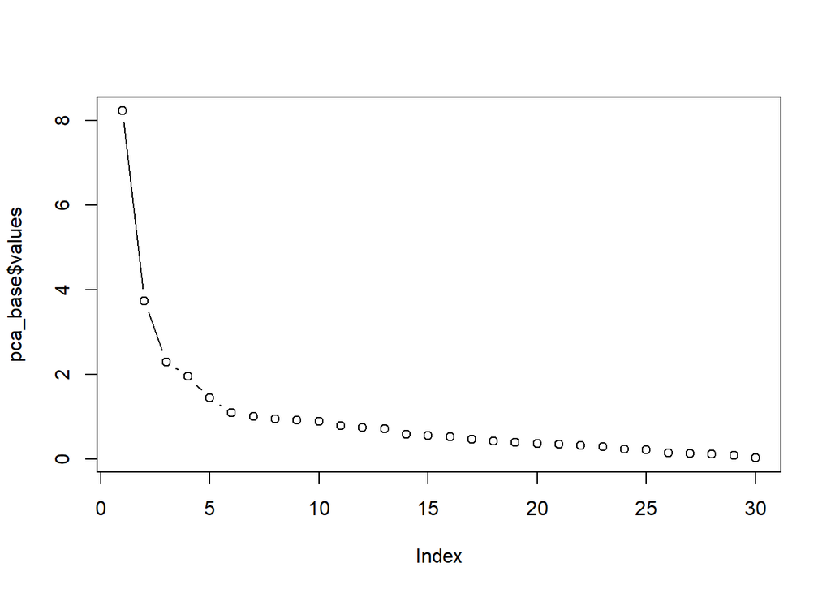

```r
plot(pca_base$values, type = "b")
```

## *2.8 Normal Distribution of Residuals*

The data were checked for the normal distribution of residuals.

```r
pca_resid <- principal(model2_tib_sc, nfactors = 3, rotate = "none")
pca_resid
```

```
## Principal Components Analysis
## Call: principal(r = model2_tib_sc, nfactors = 3, rotate = "none")
## Standardized loadings (pattern matrix) based upon correlation matrix
##                         PC1   PC2   PC3    h2    u2 com
## child_TNW              0.97  0.08  0.01 0.954 0.046 1.0
## freq_ttr              -0.84  0.13  0.04 0.716 0.284 1.1
## r_2_i_verbs           -0.16 -0.20 -0.15 0.088 0.912 2.8
## num_pos_tags           0.63  0.46  0.23 0.656 0.344 2.1
## n_dos                  0.48  0.02 -0.16 0.252 0.748 1.2
## repetition             0.58 -0.34 -0.30 0.547 0.453 2.2
## retracing              0.70 -0.40 -0.20 0.691 0.309 1.8
## fillers                0.25 -0.02  0.06 0.065 0.935 1.1
## average_syl            0.10  0.40  0.12 0.183 0.817 1.3
## mlu_words              0.27  0.51  0.43 0.515 0.485 2.5
## verb_utt               0.18  0.63  0.35 0.551 0.449 1.8
## present_progressive    0.74 -0.29  0.09 0.645 0.355 1.3
## propositions_in        0.57 -0.04 -0.03 0.333 0.667 1.0
## propositions_on        0.66  0.07  0.14 0.459 0.541 1.1
## plural_s               0.51  0.42  0.25 0.505 0.495 2.4
## irregular_past_tense   0.63  0.56 -0.38 0.853 0.147 2.6
## possessive_s           0.39  0.13  0.18 0.205 0.795 1.7
## uncontractible_copula  0.81  0.20 -0.10 0.698 0.302 1.2
## articles               0.74 -0.46 -0.16 0.779 0.221 1.8
## regular_past_ed        0.52  0.60 -0.26 0.702 0.298 2.3
## regular_3rd_person_s   0.36 -0.55  0.61 0.806 0.194 2.6
## contractible_copula   -0.04  0.25  0.36 0.196 0.804 1.8
## contractible_aux       0.03  0.22  0.46 0.264 0.736 1.4
## word_errors           -0.13 -0.10  0.01 0.027 0.973 1.9
## n_v                    0.58 -0.30 -0.28 0.503 0.497 2.0
## n_aux                  0.54 -0.43  0.12 0.491 0.509 2.0
## n_3s_v                 0.32 -0.53  0.59 0.732 0.268 2.6
## det_pl_n               0.12  0.03  0.13 0.033 0.967 2.1
## pro_aux                0.18 -0.37  0.40 0.327 0.673 2.4
## pro_3s_v               0.62  0.25 -0.19 0.484 0.516 1.5
##
##                        PC1  PC2  PC3
## SS loadings           8.22 3.74 2.30
## Proportion Var        0.27 0.12 0.08
## Cumulative Var        0.27 0.40 0.48
## Proportion Explained  0.58 0.26 0.16
## Cumulative Proportion 0.58 0.84 1.00
##
## Mean item complexity =  1.8
## Test of the hypothesis that 3 components are sufficient.
##
## The root mean square of the residuals (RMSR) is  0.07
##  with the empirical chi square  4819.62  with prob <  0
##
## Fit based upon off diagonal values = 0.94
```

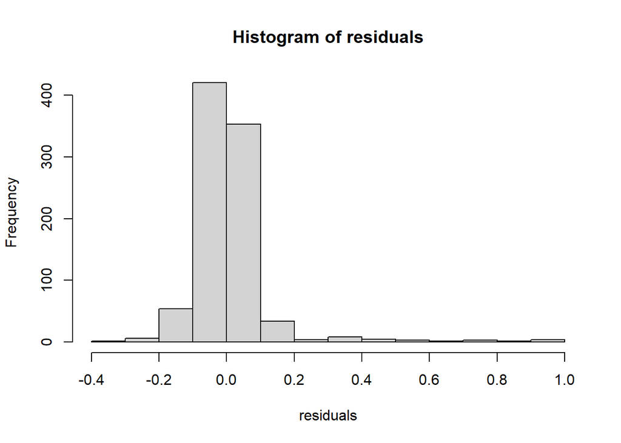

```r
corMatrix<-cor(model2_tib_sc)

residuals<-factor.residuals(corMatrix, pca_resid$loadings)

hist(residuals)
```

## *2.9 PCA with Selected Number of Components*

```r
pca_final <- principal(model2_tib_sc, nfactors = 3, rotate = "promax")
pca_final
```

```
## Principal Components Analysis
## Call: principal(r = model2_tib_sc, nfactors = 3, rotate = "promax")
## Standardized loadings (pattern matrix) based upon correlation matrix
##                         RC1   RC2   RC3    h2    u2 com
## child_TNW              0.84  0.33  0.07 0.954 0.046 1.3
## freq_ttr              -0.80 -0.10 -0.12 0.716 0.284 1.1
## r_2_i_verbs           -0.02 -0.30 -0.04 0.088 0.912 1.0
## num_pos_tags           0.32  0.67  0.02 0.656 0.344 1.4
## n_dos                  0.49  0.03 -0.10 0.252 0.748 1.1
## repetition             0.75 -0.31 -0.02 0.547 0.453 1.3
## retracing              0.83 -0.25  0.11 0.691 0.309 1.2
## fillers                0.20  0.10  0.09 0.065 0.935 1.9
## average_syl           -0.08  0.41 -0.10 0.183 0.817 1.2
## mlu_words             -0.10  0.75  0.13 0.515 0.485 1.1
## verb_utt              -0.18  0.76 -0.01 0.551 0.449 1.1
## present_progressive    0.71  0.05  0.31 0.645 0.355 1.4
## propositions_in        0.54  0.11  0.05 0.333 0.667 1.1
## propositions_on        0.51  0.33  0.15 0.459 0.541 1.9
## plural_s               0.23  0.63  0.04 0.505 0.495 1.3
## irregular_past_tense   0.56  0.33 -0.56 0.853 0.147 2.6
## possessive_s           0.23  0.33  0.13 0.205 0.795 2.1
## uncontractible_copula  0.71  0.29 -0.11 0.698 0.302 1.4
## articles               0.86 -0.25  0.18 0.779 0.221 1.3
## regular_past_ed        0.40  0.42 -0.49 0.702 0.298 2.9
## regular_3rd_person_s   0.22  0.10  0.86 0.806 0.194 1.2
## contractible_copula   -0.27  0.42  0.18 0.196 0.804 2.1
## contractible_aux      -0.24  0.49  0.29 0.264 0.736 2.2
## word_errors           -0.09 -0.10  0.05 0.027 0.973 2.4
## n_v                    0.73 -0.26 -0.02 0.503 0.497 1.3
## n_aux                  0.56 -0.10  0.38 0.491 0.509 1.8
## n_3s_v                 0.19  0.09  0.83 0.732 0.268 1.1
## det_pl_n               0.04  0.15  0.11 0.033 0.967 2.0
## pro_aux                0.10  0.05  0.56 0.327 0.673 1.1
## pro_3s_v               0.56  0.23 -0.23 0.484 0.516 1.7
##
##                        RC1  RC2  RC3
## SS loadings           7.48 3.89 2.90
## Proportion Var        0.25 0.13 0.10
## Cumulative Var        0.25 0.38 0.48
## Proportion Explained  0.52 0.27 0.20
## Cumulative Proportion 0.52 0.80 1.00
##
##  With component correlations of
##      RC1   RC2   RC3
## RC1 1.00  0.24  0.07
## RC2 0.24  1.00 -0.18
## RC3 0.07 -0.18  1.00
##
## Mean item complexity =  1.6
## Test of the hypothesis that 3 components are sufficient.
##
## The root mean square of the residuals (RMSR) is  0.07
##  with the empirical chi square  4819.62  with prob <  0
##
## Fit based upon off diagonal values = 0.94
```

```r
print.psych(pca_final, cut = 0.3, sort = TRUE)
```

```
## Principal Components Analysis
## Call: principal(r = model2_tib_sc, nfactors = 3, rotate = "promax")
## Standardized loadings (pattern matrix) based upon correlation matrix
##                       item   RC1   RC2   RC3    h2    u2 com
## articles                19  0.86             0.779 0.221 1.3
## child_TNW                1  0.84  0.33       0.954 0.046 1.3
## retracing                7  0.83             0.691 0.309 1.2
## freq_ttr                 2 -0.80             0.716 0.284 1.1
## repetition               6  0.75 -0.31       0.547 0.453 1.3
## n_v                     25  0.73             0.503 0.497 1.3
## present_progressive     12  0.71        0.31 0.645 0.355 1.4
## uncontractible_copula   18  0.71             0.698 0.302 1.4
## irregular_past_tense    16  0.56  0.33 -0.56 0.853 0.147 2.6
## pro_3s_v                30  0.56             0.484 0.516 1.7
## n_aux                   26  0.56        0.38 0.491 0.509 1.8
## propositions_in         13  0.54             0.333 0.667 1.1
## propositions_on         14  0.51  0.33       0.459 0.541 1.9
## n_dos                    5  0.49             0.252 0.748 1.1
## fillers                  8                   0.065 0.935 1.9
## verb_utt                11        0.76       0.551 0.449 1.1
## mlu_words               10        0.75       0.515 0.485 1.1
## num_pos_tags             4  0.32  0.67       0.656 0.344 1.4
## plural_s                15        0.63       0.505 0.495 1.3
## contractible_aux        23        0.49       0.264 0.736 2.2
## contractible_copula     22        0.42       0.196 0.804 2.1
## average_syl              9        0.41       0.183 0.817 1.2
## possessive_s            17        0.33       0.205 0.795 2.1
## r_2_i_verbs              3                   0.088 0.912 1.0
## det_pl_n                28                   0.033 0.967 2.0
## word_errors             24                   0.027 0.973 2.4
## regular_3rd_person_s    21              0.86 0.806 0.194 1.2
## n_3s_v                  27              0.83 0.732 0.268 1.1
## pro_aux                 29              0.56 0.327 0.673 1.1
## regular_past_ed         20  0.40  0.42 -0.49 0.702 0.298 2.9
##
##                        RC1  RC2  RC3
## SS loadings           7.48 3.89 2.90
## Proportion Var        0.25 0.13 0.10
## Cumulative Var        0.25 0.38 0.48
## Proportion Explained  0.52 0.27 0.20
## Cumulative Proportion 0.52 0.80 1.00
##
##  With component correlations of
##      RC1   RC2   RC3
## RC1 1.00  0.24  0.07
## RC2 0.24  1.00 -0.18
## RC3 0.07 -0.18  1.00
##
## Mean item complexity =  1.6
## Test of the hypothesis that 3 components are sufficient.
##
## The root mean square of the residuals (RMSR) is  0.07
##  with the empirical chi square  4819.62  with prob <  0
##
## Fit based upon off diagonal values = 0.94
```

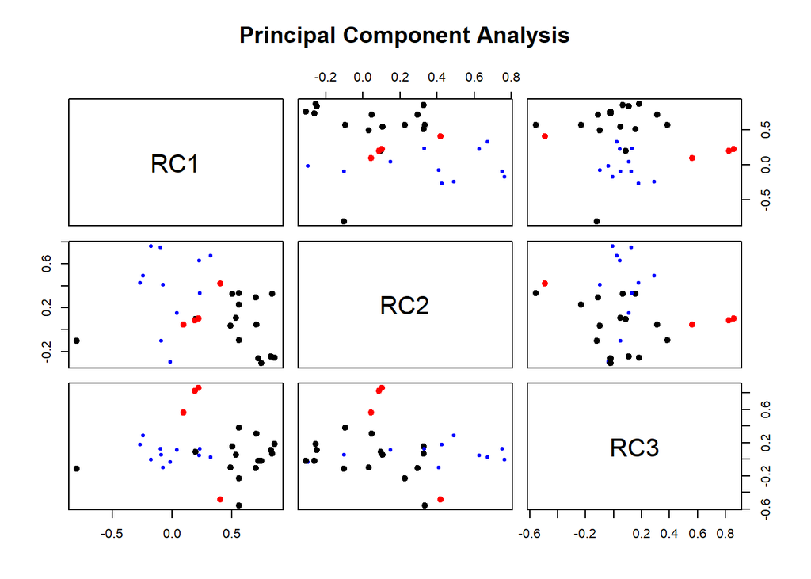

```r
plot(pca_final)
```

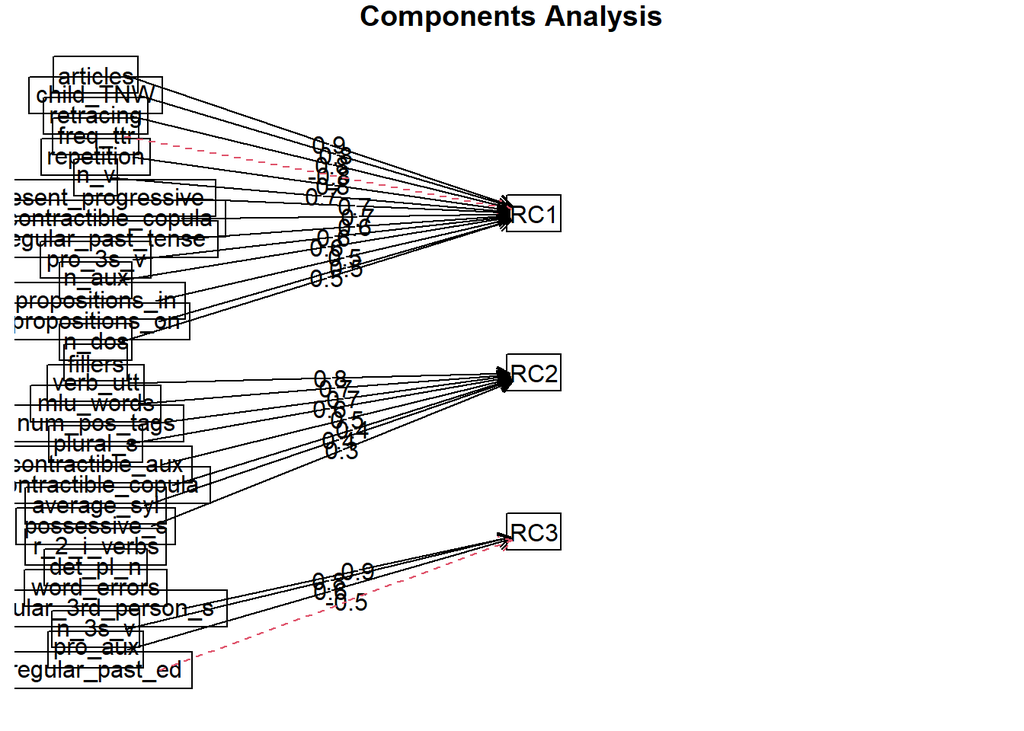

```r
fa.diagram(pca_final)
```

## *2.10 Interpretation of Components*

At this point, the components were labeled.

Component 1 contained: - articles (0.86) - child_TNW (0.84) - retracing (0.83) - freq_ttr (-0.80) - repetition (0.75) - n_v (0.73) - present_progressive (0.71) - uncontractible_copula (0.71) - irregular_past_tense (0.56) - pro_3s_v (0.56) - n_aux (0.56) - propositions_in (0.54) - propositions_on (0.51) - n_dos (0.49)

Component 1 contained frequent sentence components, and was named ‘Frequency1’ as it was thought to represent frequent utterances.

Component 2 contained: - verb_utt (0.76) - mlu_words (0.75) - num_pos_tags (0.67) - plural_s (0.63) - contractible_aux (0.49) - contractible_copula (0.42) - average_syl (0.41) - possessive_s (0.33)

Component 2 contained sentence length indicator components, and was named ‘Length2’ as it was thought to represent the length of the utterances.

Component 3 contained: - regular_3rd_person_s (0.86) - n_3s_v (0.83) - pro_aux (0.56) - regular_past_ed (-0.49)

Component 3 contained pronoun and verb agreement components, and was named ‘Agreement3’ as it was though to represent agreement between the pronouns and verb forms.

The variables fillers, r_2_i_verbs, det_pl_n, and word_errors were not strong enough to be included in any component.

```r
pca_final_scores <- as.data.frame(pca_final$scores)

pca_final_scores <- pca_final_scores %>%
  rename(Frequency1 = RC1, Length2 = RC2, Agreement3 = RC3)

str(model2_tib_sc)
```

```
## tibble [1,163 × 30] (S3: tbl_df/tbl/data.frame)
##  $ child_TNW            : num [1:1163] -0.561 -0.2272 -0.6475 -0.0748 -0.5074 ...
##  $ freq_ttr             : num [1:1163] -0.345 -0.896 0.383 -0.102 -0.849 ...
##  $ r_2_i_verbs          : num [1:1163] -0.533 -0.62 -0.537 -0.472 -0.47 ...
##  $ num_pos_tags         : num [1:1163] -1.203 -1.075 -0.82 -0.566 -1.075 ...
##  $ n_dos                : num [1:1163] -0.635 -0.635 -0.635 -0.635 -0.635 ...
##  $ repetition           : num [1:1163] -0.2076 -0.4374 -0.4374 0.0987 -0.514 ...
##  $ retracing            : num [1:1163] 0.1867 0.0803 0.0803 1.7812 -0.026 ...
##  $ fillers              : num [1:1163] 0.11 -0.795 -0.23 -0.569 -0.456 ...
##  $ average_syl          : num [1:1163] -0.1068 0.2351 0.0377 -0.2735 -1.1757 ...
##  $ mlu_words            : num [1:1163] -0.31 0.685 1.377 0.685 0.428 ...
##  $ verb_utt             : num [1:1163] -1.2785 -0.6141 0.7657 0.0843 -0.2087 ...
##  $ present_progressive  : num [1:1163] 0.1194 0.0209 0.2179 -0.2746 0.3164 ...
##  $ propositions_in      : num [1:1163] 1.6491 2.334 0.2792 0.2792 -0.0633 ...
##  $ propositions_on      : num [1:1163] -0.718 2.028 -0.718 0.197 0.197 ...
```

[output cut: 16 more lines]

## *2.11 Creation of Component CSV*

A CSV of the components was created.

```r
component_csv <- cbind(all_data_R_tib, pca_final_scores)
str(component_csv)
```

```
## 'data.frame':    1163 obs. of  67 variables:
##  $ Y                    : num  1 1 1 1 1 1 1 1 1 1 ...
##  $ filename             : chr  "fssli009.cha" "fssli058.cha" "fssli062.cha" "fssli066.cha" ...
##  $ sex                  : chr  NA NA NA NA ...
##  $ age                  : num  165 172 160 184 176 178 180 163 162 176 ...
##  $ age_years            : num  13.8 14.3 13.3 15.3 14.7 ...
##  $ corpus               : chr  "Conti4" "Conti4" "Conti4" "Conti4" ...
##  $ group                : chr  "SLI" "SLI" "SLI" "SLI" ...
##  $ child_TNW            : num  287 368 266 405 300 224 385 571 355 247 ...
##  $ child_TNS            : num  36 42 26 40 35 31 27 55 34 29 ...
##  $ examiner_TNW         : num  4 27 2 21 20 26 21 15 2 3 ...
##  $ freq_ttr             : num  0.333 0.274 0.411 0.359 0.279 0.377 0.373 0.271 0.342 0.294 ...
##  $ r_2_i_verbs          : num  0.108 0.05 0.105 0.149 0.15 ...
##  $ mor_words            : num  252 361 246 348 294 215 367 542 304 245 ...
##  $ num_pos_tags         : num  29 30 32 34 30 27 34 40 32 27 ...
```

[output cut: 53 more lines]

```r
write.csv(component_csv,"pca_scores_final_df.csv", row.names=FALSE)
```

## *2.12 Modeling Data using Component Scores*

### 2.12.1 Cross-validated model with feature selection

First, a tibble containing the new components was joined with the original data set, and filtered to only contain the SLI group (n = 267) and a random sample of the TD group (n = 267).

```r
SLI_tib <- read_csv("pca_scores_final_df.csv") %>%
  filter(Y == 1)
TD_tib <- read_csv("pca_scores_final_df.csv") %>%
  filter(Y == 0) %>%
  slice_sample(n = 267)
full_tib <- full_join(SLI_tib, TD_tib)
```

[output not shown]

```r
final_tib <- full_tib %>%
  dplyr::select (Y, Frequency1, Length2, Agreement3)

str(final_tib)
```

```
## tibble [534 × 4] (S3: tbl_df/tbl/data.frame)
##  $ Y         : num [1:534] 1 1 1 1 1 1 1 1 1 1 ...
##  $ Frequency1: num [1:534] -0.3558 -0.0176 -0.6155 -0.0118 -0.4839 ...
##  $ Length2   : num [1:534] -0.6167 -0.2205 -0.0202 -0.0494 -0.27 ...
##  $ Agreement3: num [1:534] 0.564 0.225 -0.105 -0.356 0.472 ...
```

```r
print(final_tib)
```

```
## # A tibble: 534 × 4
##        Y Frequency1 Length2 Agreement3
##    <dbl>      <dbl>   <dbl>      <dbl>
##  1     1    -0.356  -0.617      0.564
##  2     1    -0.0176 -0.221      0.225
##  3     1    -0.615  -0.0202    -0.105
##  4     1    -0.0118 -0.0494    -0.356
##  5     1    -0.484  -0.270      0.472
##  6     1    -0.637  -0.782     -0.0498
##  7     1    -0.506   1.25      -0.148
##  8     1     0.193   0.651      0.236
##  9     1    -0.284  -0.293     -0.185
## 10     1    -0.315  -0.125      0.267
## # … with 524 more rows
```

```r
set.seed(1234)

train.control <- trainControl(method = "cv", number = 10)

machinemodel_1 <- train(Y ~ .,
                        data = final_tib,
                        method = "glmStepAIC",
                        direction = "backward",
                        trControl = train.control,
                        family = "binomial")
```

[output not shown]

[output cut: 184 more lines]

```
##
## Step:  AIC=653.56
## .outcome ~ Frequency1 + Length2
##
##              Df Deviance    AIC
## - Frequency1  1   648.54 652.54
## <none>            647.56 653.56
## - Length2     1   732.28 736.28
##
## Step:  AIC=652.54
## .outcome ~ Length2
##
##           Df Deviance    AIC
## <none>         648.54 652.54
## - Length2  1   740.28 742.28
```

```r
summary(machinemodel_1)
```

```
##
## Call:
## NULL
##
## Deviance Residuals:
##     Min       1Q   Median       3Q      Max
## -2.1837  -1.0530   0.1066   1.0077   2.9379
##
## Coefficients:
##             Estimate Std. Error z value Pr(>|z|)
## (Intercept) -0.19665    0.09764  -2.014    0.044 *
## Length2     -0.95108    0.11462  -8.298   <2e-16 ***
## ---
## Signif. codes:  0 '***' 0.001 '**' 0.01 '*' 0.05 '.' 0.1 ' ' 1
##
## (Dispersion parameter for binomial family taken to be 1)
##
##     Null deviance: 740.28  on 533  degrees of freedom
## Residual deviance: 648.54  on 532  degrees of freedom
## AIC: 652.54
##
## Number of Fisher Scoring iterations: 4
```

```r
machinemodel_1$bestTune
```

```
##   parameter
## 1      none
```

```r
machinemodel_1$results
```

```
##   parameter      RMSE  Rsquared       MAE     RMSESD RsquaredSD     MAESD
## 1      none 0.4579725 0.1736177 0.4202698 0.02357925   0.080598 0.0209655
```

```r
summary(machinemodel_1$finalModel)
```

```
##
## Call:
## NULL
##
## Deviance Residuals:
##     Min       1Q   Median       3Q      Max
## -2.1837  -1.0530   0.1066   1.0077   2.9379
##
## Coefficients:
##             Estimate Std. Error z value Pr(>|z|)
## (Intercept) -0.19665    0.09764  -2.014    0.044 *
## Length2     -0.95108    0.11462  -8.298   <2e-16 ***
## ---
## Signif. codes:  0 '***' 0.001 '**' 0.01 '*' 0.05 '.' 0.1 ' ' 1
##
## (Dispersion parameter for binomial family taken to be 1)
##
##     Null deviance: 740.28  on 533  degrees of freedom
## Residual deviance: 648.54  on 532  degrees of freedom
## AIC: 652.54
##
## Number of Fisher Scoring iterations: 4
```

From the machine model, the coefficients can then be checked for suppression effects.

### 2.12.2 Suppression Effects

```r
coef(machinemodel_1$finalModel, 1)
```

```
## (Intercept)     Length2
##  -0.1966481  -0.9510809
```

### 2.12.3 Produce the Predicted and Actual Values

```r
probabilities <- function(co_ef){
  odds <- exp(co_ef)
  prob <- odds/(1+odds)
  return(prob)
}


estimates <- c(-0.9366501,-0.1851341)

probabilities(estimates)
```

```
## [1] 0.2815775 0.4538482
```

```r
predicted <- unname(machinemodel_1$finalModel$fitted.values)

final_tib$predicted.probabilities<-predicted

final_tib <- final_tib %>%
  mutate(actual = ifelse(Y == "0", 1, 2)) %>% # if Y is 0, assign 1, otherwise 2
  mutate(predicted = ifelse(predicted.probabilities < .50, 1, 2))

final_tib$predicted <- as.factor(final_tib$predicted)
final_tib$actual <- as.factor(final_tib$actual)

str(final_tib)
```

```
## tibble [534 × 7] (S3: tbl_df/tbl/data.frame)
##  $ Y                      : num [1:534] 1 1 1 1 1 1 1 1 1 1 ...
##  $ Frequency1             : num [1:534] -0.3558 -0.0176 -0.6155 -0.0118 -0.4839 ...
##  $ Length2                : num [1:534] -0.6167 -0.2205 -0.0202 -0.0494 -0.27 ...
##  $ Agreement3             : num [1:534] 0.564 0.225 -0.105 -0.356 0.472 ...
##  $ predicted.probabilities: num [1:534] 0.596 0.503 0.456 0.463 0.515 ...
##  $ actual                 : Factor w/ 2 levels "1","2": 2 2 2 2 2 2 2 2 2 2 ...
##  $ predicted              : Factor w/ 2 levels "1","2": 2 2 1 1 2 2 1 1 2 1 ...
```

```r
table(final_tib$actual)
```

```
##
##   1   2
## 267 267
```

### 2.12.4 Creation of the Confusion Matrix

The confusion marix was created using CARET.

```r
confusionMatrix(final_tib$actual, final_tib$predicted,
                mode = "everything",
                positive="1") # positive is SLI
```

```
## Confusion Matrix and Statistics
##
##           Reference
## Prediction   1   2
##          1 180  87
##          2  82 185
##
##                Accuracy : 0.6835
##                  95% CI : (0.6422, 0.7228)
##     No Information Rate : 0.5094
##     P-Value [Acc > NIR] : 2.574e-16
##
##                   Kappa : 0.367
##
##  Mcnemar's Test P-Value : 0.7583
##
##             Sensitivity : 0.6870
##             Specificity : 0.6801
##          Pos Pred Value : 0.6742
##          Neg Pred Value : 0.6929
##               Precision : 0.6742
##                  Recall : 0.6870
##                      F1 : 0.6805
##              Prevalence : 0.4906
##          Detection Rate : 0.3371
##    Detection Prevalence : 0.5000
##       Balanced Accuracy : 0.6836
##
##        'Positive' Class : 1
##
```

```r
mosaic_table <- table(final_tib$actual, final_tib$predicted)
mosaic_table #check on that table
```

```
##
##       1   2
##   1 180  87
##   2  82 185
```

### 2.11.5 Visualize using a Mosaic Plot

The final model was visualized by creating a confusion matrix.

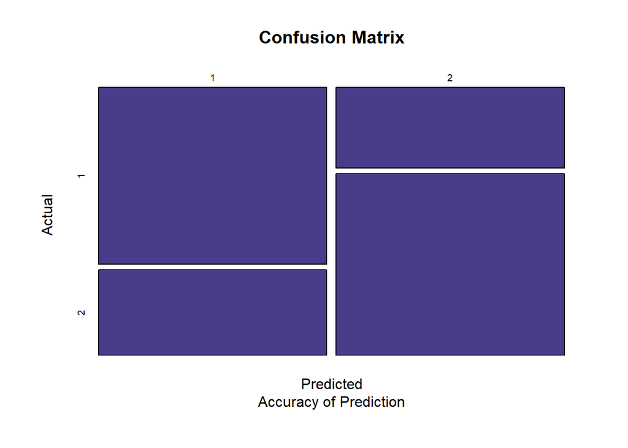

```r
mosaicplot(mosaic_table,
           main = "Confusion Matrix",
           sub = "Accuracy of Prediction",
           xlab = "Predicted",
           ylab = "Actual",
           color = "darkslateblue",
           border = "black")
```

# **3 Discussion**

Future research should consider using more components to predict SLI status, or create components from different measures taken from the transcripts such as the number of unique subjects or the number of unique subject-verb combinations [6, 7]

This research was limited in the small SLI sample available (n = 267), and the pre-determined variables that went into the PCA from the available data set.

# **4 References**

1. Rodgers, M. E. FinalProject_PCA_ML_LogisticRegression_TranscriptData. https://github.com/Mary-E-Rodgers/FinalProject_PCA_ML_LogisticRegression_TranscriptData
2. National Institute of Health, Deafness and Other Communication Disorders. NIDCD Fact Sheet: Voice Speech and Language, Specific Language Impairment. U.S. Department of Health and Human Services.
3. Curtis, P. R., Roberts, M. Y., Estabrook, R., & Kaiser, A. P. The longitudinal effects of early language intervention on Children’s Problem Behaviors. *Child Development*. 2017; 90(2): 576-592.
4. Ervin, M. SLI: what we know and why it matters. *American Speech and Hearing Association*. 2001; 6(12).
5. Zimmerman, I. L., Steiner, V. G., & Pond, R. E. Preschool Language Scale, Fifth Edition (PLS-5) [Database record]. PsycTESTS. 2011.
6. Hadley, P. Exploring sentence diversity at the boundary of typical and impaired language abilities. *Journal of Speech, Language, and Hearing Research*. 2020; 63: 3236-3251.
7. Hadley, P., McKenna, M., & Rispoli, M. Sentence diversity in early language development: Recommendations for target selection and progress monitoring. American Journal of Speech-Language. 2018; 27: 553-565.
8. RStudio Team. RStudio: Integrated Development for R. RStudio, PBC, Boston, MA, 2020.
9. Dgoke1. (2018). Diagnose Specific Language Impairment in Children, Version 6. Retrieved April 21, 2023 from https://www.kaggle.com/datasets/dgokeeffe/specific-language-impairment.
10. D. Wetherell, N. Botting, and G. Conti-Ramsden. Narrative skills in adolescents with a history of SLI in relation to non-verbal IQ scores. *Child Language Teaching and Therapy*. 2007; 23(1): 95--113.
11. Schneider, D. Hayward, and R. V. Dub. Storytelling from pictures using the Edmonton Narrative Norms Instrument, 2006.
12. Gillam, R. Pearson, N. Test of Narrative Language. Austin, TX: Pro-Ed Inc., 2004.
13. Wickham, H., Averick, M., Bryan, J., Chang, W., McGowan, L. D., François, R., Grolemund, G., Hayes, A., Henry, L., Hester, J., Kuhn, M., Pedersen, T. L., Miller, E., Bache, S. M., Müller, K., Ooms, J., Robinson, D., Seidel, D. P., Spinu, V., Takahashi, K., Vaughan, D., Wilke, C., Woo, K., Yutani, H. (2019). "Welcome to the tidyverse." _Journal of Open Source Software_, *4*(43), 1686. doi:10.21105/joss.01686 https://doi.org/10.21105/joss.01686.
14. Wickham, H.. ggplot2: Elegant Graphics for Data Analysis. Springer-Verlag New York, 2016.
15. Wickham, H., François, R., Henry, L., Müller, K., Vaughan, D. (2023). _dplyr: A Grammar of Data Manipulation_. R package version 1.1.0, https://CRAN.R-project.org/package=dplyr.
16. Kuhn, M. (2022). _caret: Classification and Regression Training_. R package version 6.0-93, https://CRAN.R-project.org/package=caret.
17. Fox, J., Weisberg, S. (2019). An {R} Companion to Applied Regression, Third Edition. Thousand Oaks CA: Sage. URL: https://socialsciences.mcmaster.ca/jfox/Books/Companion/
18. Grömping, U. (2006). Relative Importance for Linear Regression in R: The Package relaimpo. Journal of Statistical Software, 17(1), 1--27.
19. Peterson, B. G., Carl, P. (2020). _PerformanceAnalytics: Econometric Tools for Performance and Risk Analysis_. R package version 2.0.4, https://CRAN.R-project.org/package=PerformanceAnalytics.
20. JFriedman, J., Hastie, T., Tibshirani, R. (2010). Regularization Paths for Generalized Linear Models via Coordinate Descent. Journal of Statistical Software, 33(1), 1-22. URL https://www.jstatsoft.org/v33/i01/.
21. Revelle, W. (2023). _psych: Procedures for Psychological, Psychometric, and Personality Research_. Northwestern University, Evanston, Illinois. R package version 2.3.3, https://CRAN.R-project.org/package=psych.
22. Wickham, H. (2022). _stringr: Simple, Consistent Wrappers for Common String Operations_. R package version 1.5.0, <[https://CRAN.R-project.org/package=stringr](https://cran.r-project.org/package=stringr)>.
23. Kaiser, A., Roberts, M, & Hadley, P. Maximizing outcomes for preschoolers with developmental language disorder: Testing the effects of a sequentially targeted naturalistic intervention. In Preparation. ```